# Final Prediction

Annelies Quinton

2022-11-07

# Intro

This blog includes my final prediction for the 2022 Midterm elections. Over the past 10 weeks, I have looked at various variables, assessing their predictive power, with the goal of creating a prediction model. The outcome of my model is a national vote share prediction.

# The Last 10 Weeks

Before I share my model, I think it is important to summarize what variables I have considered before arriving at my final model. I started by looking at economic fundamentals, assessing GDP, unemployment, and inflation. I found that subsetting the data to the last quarter of the election cycle was the most predictive( Healy and Lenz, 2014).. I then looked at polling data, specifically the average generic ballot within the 50 days prior to the election. I then shifted to looking at district level variables. This included incumbency and expert ratings. I also considered the “air war” and advertising trends (cost, tone, purpose) grouped by district. Finally, I considered demographics and turnout at both a district and national level. Each of these variables include different variations, resulting in another group of variables to consider. For example, with incumbent data, I looked at the incumbent House party, the incumbent president party, and when these parties match. The challenge became choosing the variables.

# Building My Final Model

When deciding on my final model, I built three variations of a similar model. I will walk through my thought process for choosing which variation I selected.

The final variables I considered were:

1. **Average democrat polling (50 days):** This the average of the democratic generic ballot polls from 50 days prior to the election. The generic ballot is an effective way of understanding the public’s view and filtering for the days leading up to the election gets a better sense of the true pulse of the country (Bafumi, Erikson, Wlezien, 2018).
2. **President party:** This is a binary variable with 1 being Democrat and -1 being Republican. Often the party in power is [punished](https://fivethirtyeight.com/features/why-the-presidents-party-almost-always-has-a-bad-midterm/) during the midterms.
3. **Presidential and party match:** A binary variable with 1 being the parties match and -1 being the parties don’t match. This is a continuation of the previous variable, but my hypothesis is that if the party matches there will be a larger punishment.
4. **Change in percent of white voters:** This the white vote share from that election minus the white vote share from the previous election. As seen in lab, white and Hispanic voters had the strongest coefficient toward prediction democratic vote share.
5. **Change in Hispanic voters:** This the Hispanic vote share from that election minus the Hispanic vote share from the previous election.

Below I show the regression outputs for the three models I considered.

```
##
## Regression Results
## ============================================================================================================
##                                                                     Dependent variable:
##                                                -------------------------------------------------------------
##                                                             Democratic Major Vote Share Percent
##                                                        (1)                  (2)                 (3)
## ------------------------------------------------------------------------------------------------------------
## Change in percent of white voters                     -1.0**              -2.2**
##                                                       (0.3)                (0.7)
##
## Change in percent of Hispanic voters                  1.1***               1.7**
##                                                       (0.2)                (0.6)
##
## Presidential Party                                   -3.1***              -2.4**              -2.2***
##                                                       (0.3)                (0.8)               (0.5)
##
## President and House Party Match                      -2.7***
##                                                       (0.4)
##
## Average Democrat Polling Support (50 days out)         -0.2                 0.1                0.6***
##                                                       (0.1)                (0.3)               (0.1)
##
## Constant                                             57.0***               42.7*              23.0***
##                                                       (5.5)               (16.7)               (7.1)
##
## ------------------------------------------------------------------------------------------------------------
## Observations                                            10                  10                   14
## R2                                                     1.0                  0.9                 0.8
## Adjusted R2                                            1.0                  0.9                 0.8
## Residual Std. Error                                0.4 (df = 4)        1.3 (df = 5)        1.9 (df = 11)
## F Statistic                                    187.4*** (df = 5; 4) 20.3*** (df = 4; 5) 21.4*** (df = 2; 11)
## ============================================================================================================
## Note:                                                                            *p<0.1; **p<0.05; ***p<0.01
```

# Model Validation

## RMSE

To evaluate the models, I first calculated the root mean square error (rmse) value.

```
## [1] 0.8164966
```

```
## [1] 0.8164966
```

```
## [1] 0.9660918
```

## Plotting Residuals

I then plotted the residuals for each model between the predicted and the actual values. The plots for model 1 and model 2 begin after 1982 because of limited demographic data. The plot shows that fit 1 appears to most directly correspond to the actual values.

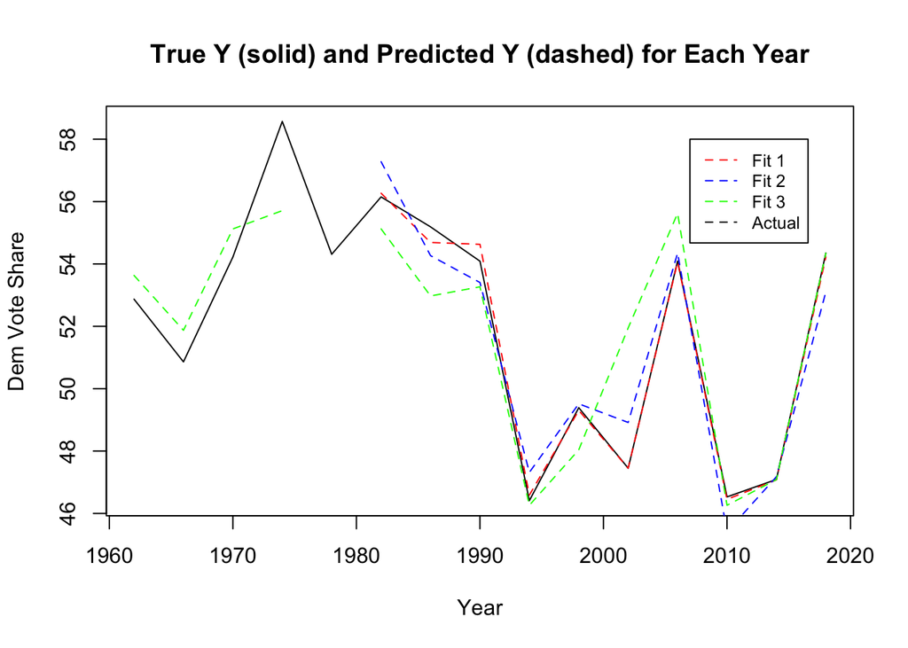

## Cross Validation

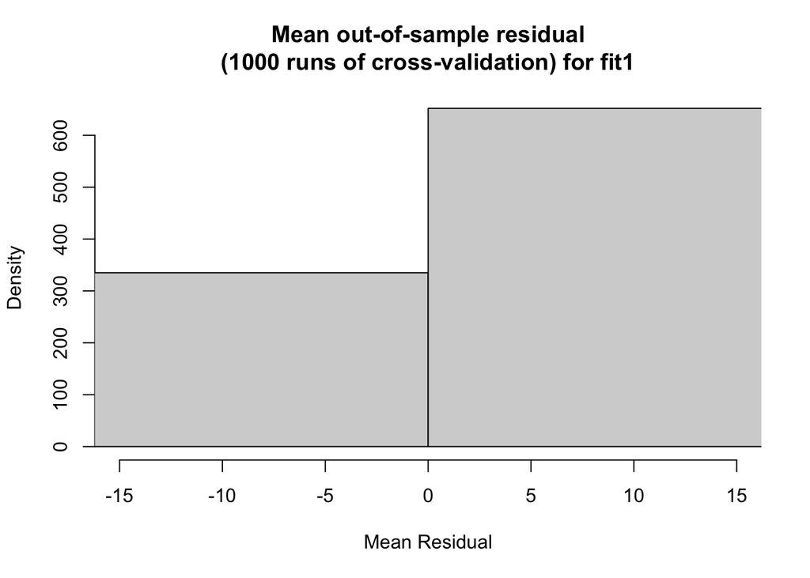

```
## [1] 5.156982
```

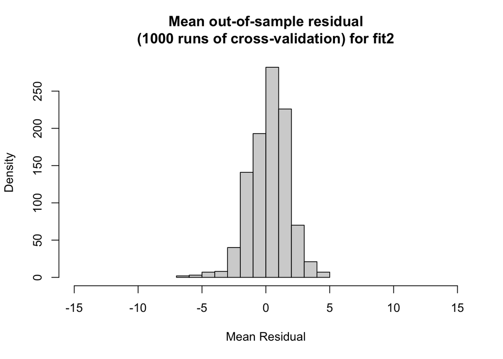

```
## [1] 1.216998
```

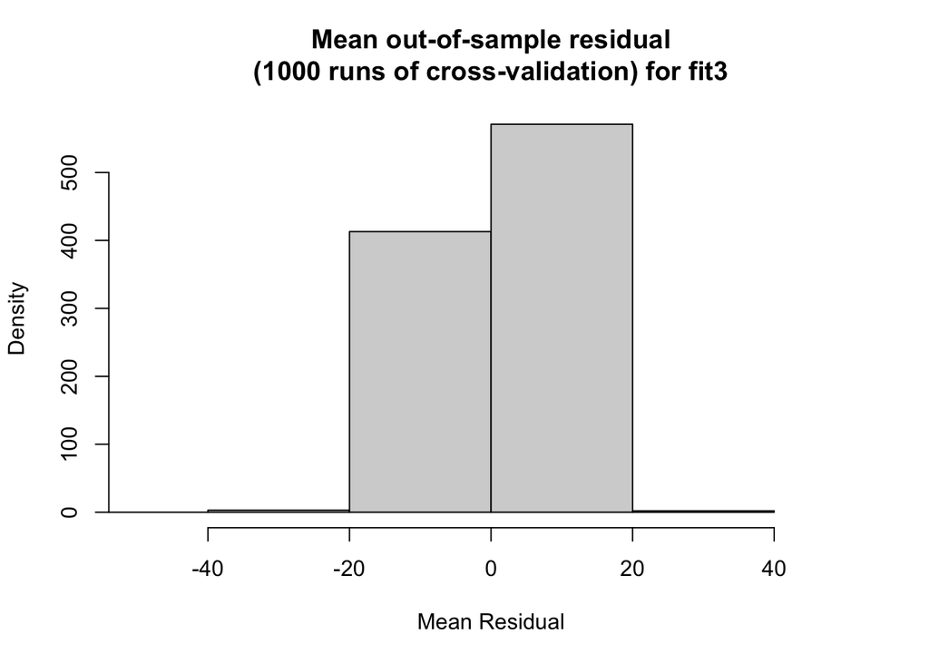

```
## [1] 4.214247
```

# Choosing a model

Each model performed well in separate validation testing. To choose a model, I used the chart below to average their performance. From this, model 1 and model 3 had the highest score.

[output not shown]

My official prediction will be off of model 1, however, I am interested in evaluating both models’ success after the election. The equations for my models are:

## Model 1:

Democratic Major Vote Share = 57 -1(change in white voters) +1.1(change in Hispanic voters) -3.1(presidential party) -2.7(president house match) -0.2(polling)

## Model 3:

Democratic Major Vote Share = 23 - 2.2(president party) + .6(polls)

## Discussion of Coefficients

From these models, we see that the presidential party has the greatest magnitude in both models. Conversely, polling has the lowest magnitude. Polling as the lowest is a surprise to me because I would expect this variable to be the closest to the actual outcome. However, polling is often deemed fairly unreliable in predictions(Gelman and King, 1993). With regard to model 1, it is interesting that the presidential house match has a smaller coefficient than the presidential party. I would have thought this match would make people want to punish the incumbent party even more (as seen with the presidential party).

# Prediction

Below I show the predicted democratic majority vote share and republican majority vote share and their confidence intervals.

## Model 1

The graph shows a republican majority, with fairly small intervals.

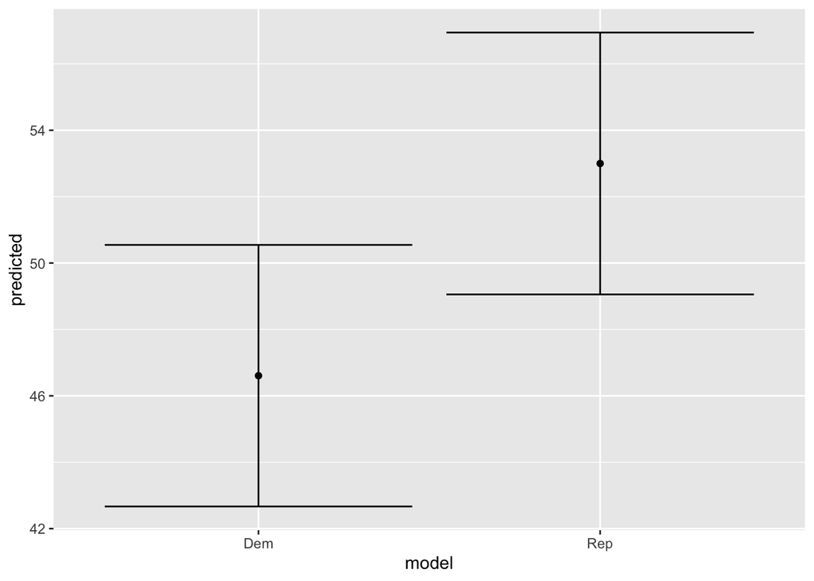

## Model 3

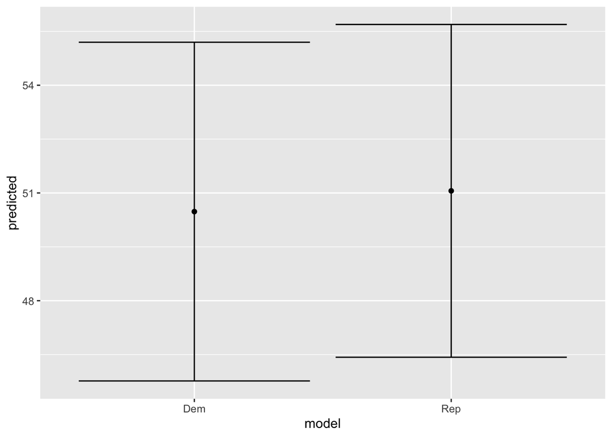